# 第7回 総合演習：データを選び、しきい値を誤りの重さで決める

ネットショップの訪問から、購入を見分ける

# 導入

## 第6回はSMS、今日は買い物

① 今日のデータ●○

- 第6回は、携帯電話のメッセージから、迷惑かどうかを見分けた
- 今日は総合演習。データを選ぶところから、1本の解析を通す
- 期末レポートでやることを、ひと通り先にやってみる

## 公開データは、自分で選べる

① 今日のデータ●●

- 世の中には、誰でも使える公開データが山ほどある
- 第6回のSMSも、UCI機械学習リポジトリという置き場のデータだった
- 今日は、その置き場から、データを選ぶところを見せる

## ネットショップの訪問

② 場面●○○

- ネットショップには、毎日たくさんの人が訪れる
- ページを見て回り、買う人もいれば、何も買わずに帰る人もいる
- 訪問の様子から、買うかどうかを見分けられないか

## 決めたいこと

② 場面●●○

- 購入しそうな訪問に、チャットの担当者が声をかけたい
- 担当者の数は限られる。誰にでも声をかけるわけにはいかない
- どの訪問に声をかけるかを、確率で決めたい

## 2つの誤り

② 場面●●●

- 買う気のある訪問に、声をかけそびれる（見逃し）
- 買わない訪問に、担当者の時間を使う（誤検出）
- 2つの誤りの重さは、同じではない

## 手元のデータ

③ 手元のデータ●○

- Online Shoppers Purchasing Intention：あるネットショップの1年間の訪問
- 1行が1回の訪問。見たページの数と時間、ページ価値などの列
- 12,330件。最後の列が、購入したかどうか

## データをのぞく

③ 手元のデータ●●

|  | 商品ページ数 | 商品ページ時間 | 離脱率 | ページ価値 | 週末 | 購入 |
| --- | --- | --- | --- | --- | --- | --- |
| 0 | 1 | 0.0 | 0.2 | 0.0 | 0 | 0 |
| 1 | 2 | 64.0 | 0.1 | 0.0 | 0 | 0 |
| 2 | 1 | 0.0 | 0.2 | 0.0 | 0 | 0 |

- 12本の列から6本を選んで表示した。先頭の3件は、どれも商品ページを1〜2枚見て、買わずに帰った

## 最後に出す答え

④ 今日の問い●○

- 訪問の様子から、購入をどのくらい見分けられるか
- 見分けたとして、確率をどこで切って、声をかける訪問を決めるか

## 今日の問い

④ 今日の問い●●

ネットショップの訪問から、購入を見分けられるか。見分けたとして、どこで切ればよいか？

## もう1つのねらい：関数

⑤ もう1つのねらい●

- 解析の手順を関数にまとめ、入力を替えて何度も呼べるようになる
- 「列を選ぶ → 交差検証で確率 → AUC」を、1つの関数にする
- お手本ごとに、コードを1行ずつ読み、変数の中身を見る

# 今日の一周

## 結果だけで一度通す

⑥ 今日の一周●○○○○○○○○

- まず、今日の解析を、結果だけで一度通して見る
- コードはあとで。どんな結論になるかを先に知っておく

## 一周①：データを選ぶ

⑥ 今日の一周●●○○○○○○○

| 候補 | 1行 | 件数 | 答えの割合 | 出どころ |
| --- | --- | --- | --- | --- |
| ネットショップ | 訪問1回 | 12,330 | 購入15.5% | 実際の訪問 |
| 工作機械 | 加工1回 | 10,000 | 故障3.4% | 作ったデータ |
| きのこ | きのこ1本 | 61,069 | 毒55.5% | 作ったデータ |

- UCIで3本を比べ、実際の記録のネットショップを選ぶ

## 一周②：何もしなくても0.845

⑥ 今日の一周●●●○○○○○○

```
購入の割合 0.155
全部「買わない」と言ったときの正解率 0.845
```

- 購入は6〜7件に1件。正解率だけでは分からない（第6回）

## 一周③：12本の列で確率を出す

⑥ 今日の一周●●●●○○○○○

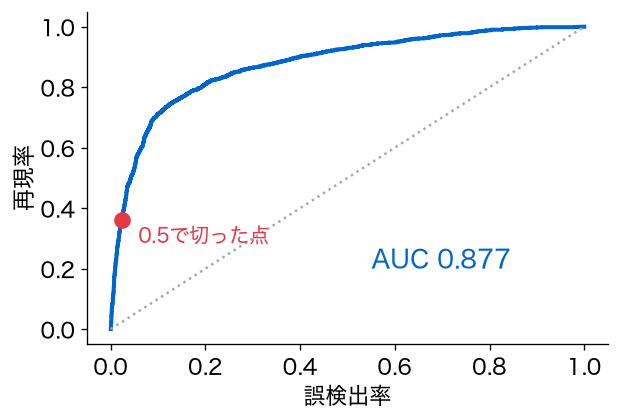

- ロジスティック回帰で購入の確率を出す。AUCは0.877

## 一周④：えっ、1本でほぼ決まる

⑥ 今日の一周●●●●●○○○○

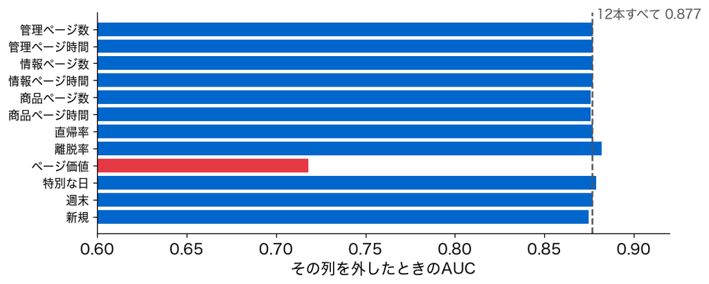

- 列を1本ずつ外すと、ページ価値を外したときだけ、0.718まで下がる

## 一周⑤：説明を読む

⑥ 今日の一周●●●●●●○○○

- ページ価値は、購入の売上から計算された値だった
- いつの購入から計算したかで、使ってよいかが変わる
- 説明には書いていない。仮定を置いて使い、その仮定を書き添える

## 一周⑥：重さでしきい値を決める

⑥ 今日の一周●●●●●●●○○

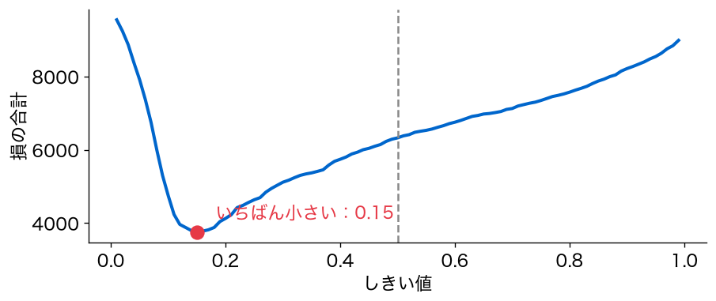

- 見逃しを誤検出の5倍と置くと、損がいちばん小さいのは0.15で切るとき

## 一周⑦：年末にも使える？

⑥ 今日の一周●●●●●●●●○

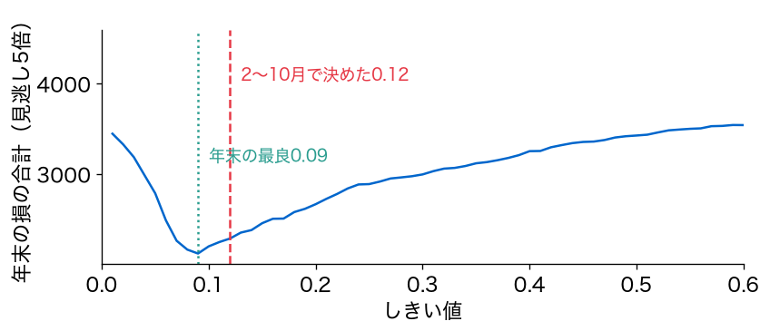

- 2〜10月で決めたしきい値は、年末（11・12月）には、損がいちばん小さい所からずれる

## 一周は5つの段

⑥ 今日の一周●●●●●●●●●

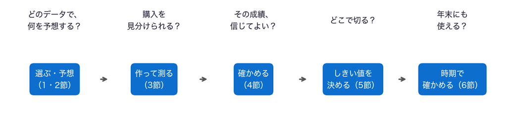

- このあと、5つの段の中身を、1つずつ開けていく

## 問いとやること①②

⑦ 問いとやること●○

- 選ぶ・予想：どのデータで、何を予想する？ → UCIで候補を比べて選び、読み込み、予想を書く（1・2節）
- 作って測る：購入を見分けられる？ → 12本の列で確率を出し、混同行列とAUCで測る（3節）

## 問いとやること③④⑤

⑦ 問いとやること●●

- 確かめる：その成績、信じてよい？ → 手順を関数にし、列を1本ずつ外す。説明を読む（4節）
- しきい値を決める：どこで切る？ → 2つの誤りに重さを置き、損の合計がいちばん小さいところで切る（5節）
- 時期で確かめる：年末にも使える？ → 2〜10月で式としきい値を決め、11・12月に当てる（6節）

## 今日の進め方

⑧ 今日の進め方●

- 段ごとに、スライドで聞く → ノートで実行して答える
- 段の終わりの「ノートへ」で、予想を書き、1か所を替えて実行し、予想と比べる
- 予想は外れてかまわない

# 0. 準備

## まずは道具を呼び出す

- 0節は、道具を呼び出すだけ。ノートで1節と続けて実行する
- UCIのデータを取ってくる道具`ucimlrepo`も、ここで入れる

# 1. どのデータを使う？

## 段1：選ぶ・予想

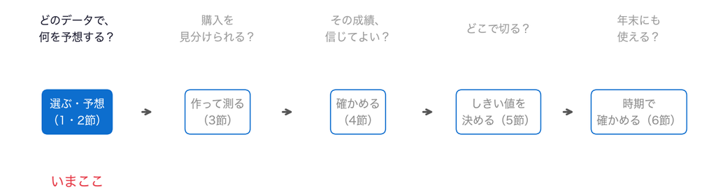

- 問い：どのデータで、何を予想するか
- まず、公開データの置き場から、データを選ぶ

## UCI機械学習リポジトリ

1節 ① データの置き場●

- 1987年から、研究に使われたデータを集めて公開している置き場
- 1つのデータに1つのページがあり、データの番号が付いている
- 第6回のSMSも、ここのデータ。表だけでなく、文章や画像のデータもある

## 探し方①：キーワードで探す

1節 ② 探し方●○○

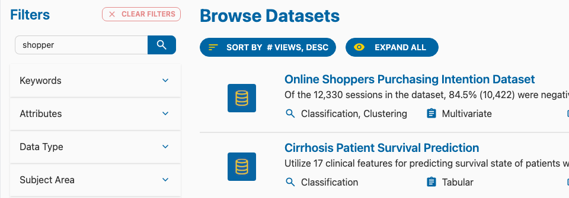

- 上の「Search datasets」か、左の検索欄に、英語の言葉を入れる（ここでは`shopper`）

## 探し方②：絞り込みで探す

1節 ② 探し方●●○

- 左の「Filters」を開くと、条件で候補を絞り込める
- Task：使いたい手法。Classification（分類）・Regression（回帰）・Clustering（クラスタリング）
- Subject Area（分野）、# Instances（件数）、Python（Colabからそのまま取り込める）

## 探し方③：データのページを開く

1節 ② 探し方●●●

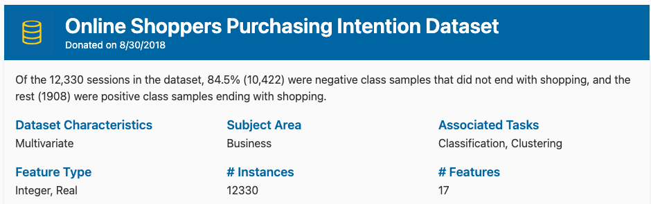

- 分野（Subject Area）・手法（Associated Tasks）・件数（# Instances）。右にライセンス
- 名前だけで決めない。ページの説明まで読む

## URLの中に、データの番号

1節 ③ 番号●○

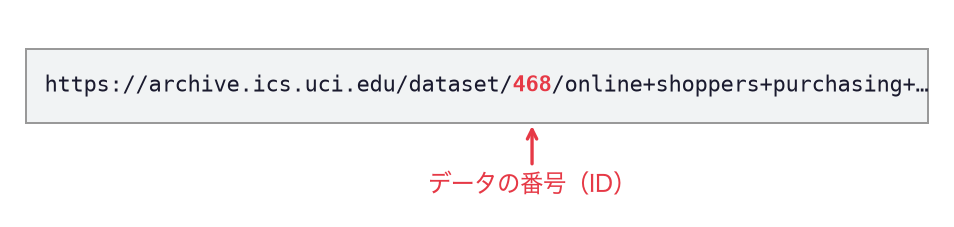

- データのページのURLの、`/dataset/`の次の数が、データの番号（ID）
- ネットショップは468。この番号を、Colabで`fetch_ucirepo(id=468)`に渡す

## 取り込むコードのボタン

1節 ③ 番号●●

[figure not shown]

- ページ右上の「IMPORT IN PYTHON」を押すと、Colabに貼るコードが出る（前半）

```python
from ucimlrepo import fetch_ucirepo
online_shoppers_purchasing_intention_dataset = fetch_ucirepo(id=468)
X = online_shoppers_purchasing_intention_dataset.data.features
y = online_shoppers_purchasing_intention_dataset.data.targets
```

- コピーしてColabに貼れば、そのまま取ってこられる。番号は2行目の`id=468`

## お手本：Colabの中で探す

1節 ④ Colabで探す●○○○

```python
from ucimlrepo import list_available_datasets
list_available_datasets(search='shopper')
```

```
----------------------------------------------------------------
The following datasets are available for search query "shopper":
----------------------------------------------------------------
Dataset Name                                    ID
------------                                    --
Online Shoppers Purchasing Intention Dataset    468
```

## 1行ずつ：Colabの中で探す

1節 ④ Colabで探す●●○○

```python
from ucimlrepo import list_available_datasets
list_available_datasets(search='shopper')
```

- 1行目：UCIのデータの一覧を出す道具`list_available_datasets`を呼び出す
- 2行目：名前に`shopper`を含み、Colabから取り込めるデータの、名前と番号（ID）を表示する

## お手本：分野で探す

1節 ④ Colabで探す●●●○

```python
list_available_datasets(area='Business')
```

```
-------------------------------------
The following datasets are available:
For subject area: Business
-------------------------------------
Dataset Name                                    ID
------------                                    --
Credit Approval                                 27
Japanese Credit Screening                       28
Statlog (Australian Credit Approval)            143
Blood Transfusion Service Center                176
Wine Quality                                    186
Bank Marketing                                  222
ISTANBUL STOCK EXCHANGE                         247
Wholesale customers                             292
…（このあとにも続く）
```

- `area`は分野（Subject Area）。ほかに`'Health and Medicine'`・`'Social Science'`など

## 重要：データの番号の見つけ方

1節 ④ Colabで探す●●●●

サイトでキーワードか絞り込みでデータを探し、そのページのURLの`/dataset/`の次の数を読む。Colabの中なら、`list_available_datasets`で名前と番号が出る。

## ページで見ること①：中身

1節 ⑤ ページで見ること●○○

- 1行は何か（1人・1回・1つ）
- 答えの列はどれか。2択か、量か
- 件数と、答えの割合。少ない側が少なすぎないか

## ページで見ること②：出どころ

1節 ⑤ ページで見ること●●○

- ライセンス（使ってよい条件）と、引用する文献
- 実際の記録か、作ったデータ（合成データ）か
- 列ごとの説明。どうやって測った値か

## ページで見ること③：扱い

1節 ⑤ ページで見ること●●●

- 欠測はあるか
- 人を判定するデータ（審査・診断など）は、扱いに配慮が要る
- 授業や期末レポートでは、身近で、人を判定しないデータが扱いやすい

## 候補を3本、表で比べる

1節 ⑥ 候補を比べる●○○○○

| 候補 | 1行 | 件数 | 答えの割合 | 出どころ |
| --- | --- | --- | --- | --- |
| ネットショップ | 訪問1回 | 12,330 | 購入15.5% | 実際の訪問 |
| 工作機械 | 加工1回 | 10,000 | 故障3.4% | 作ったデータ |
| きのこ | きのこ1本 | 61,069 | 毒55.5% | 作ったデータ |

- どれも、2択を当てる分類のデータ。ライセンスはどれもCC BY 4.0

## 件数と割合を確かめる

1節 ⑥ 候補を比べる●●○○○

```
601 10000 件 {0: 0.966, 1: 0.034}
848 61069 件 {'p': 0.555, 'e': 0.445}
```

- ページの件数と答えの割合は、取ってきて確かめられる（工作機械は故障の列、きのこは毒（p）の列）

## 工作機械は、作ったデータ

1節 ⑥ 候補を比べる●●●○○

- 説明に「synthetic dataset」（合成データ）とある
- 本物の工場の記録は手に入りにくいので、それらしく作った、と書いてある
- 作ったデータからの発見は、作った人の決めごとの発見かもしれない

## きのこも、作ったデータ

1節 ⑥ 候補を比べる●●●●○

- 説明に「61069 hypothetical mushrooms」（架空のきのこ）とある
- 図鑑のきのこの種をもとに、それらしく作ったデータ
- 列20本のうち、数の列は3本。残りは形や色の名前

## ネットショップに決める

1節 ⑥ 候補を比べる●●●●●

- 実際のネットショップの、1年間の訪問の記録
- 1行が身近で、購入は15.5%。少なすぎず、偏りもある
- 数の列が10本あり、今日の道具でそのまま扱える

## お手本：UCIから読み込む

1節 ⑦ 読み込む●○○○○

```python
from ucimlrepo import fetch_ucirepo
uci = fetch_ucirepo(id=468)
raw = pd.concat([uci.data.features, uci.data.targets], axis=1)
print(raw.shape)
```

```
(12330, 18)
```

- データの番号468で、ネットショップの表を取ってくる

## 1行ずつ：UCIから読み込む①

1節 ⑦ 読み込む●●○○○

```python
from ucimlrepo import fetch_ucirepo
uci = fetch_ucirepo(id=468)
raw = pd.concat([uci.data.features, uci.data.targets], axis=1)
print(raw.shape)
```

- 1行目：UCIのデータを取ってくる道具`fetch_ucirepo`を呼び出す
- 2行目：データの番号468を渡して取ってきて、`uci`にしまう

## 1行ずつ：UCIから読み込む②

1節 ⑦ 読み込む●●●○○

```python
from ucimlrepo import fetch_ucirepo
uci = fetch_ucirepo(id=468)
raw = pd.concat([uci.data.features, uci.data.targets], axis=1)
print(raw.shape)
```

- 3行目：特徴の表と答えの表を、横につなぐ（`pd.concat`、`axis=1`は横）
- 4行目：表の形（行の数、列の数）を表示する

## fetch_ucirepoがしていること

1節 ⑦ 読み込む●●●●○

- データのページに置いてある表を、ネットから取ってくる
- 特徴の列（`uci.data.features`）と、答えの列（`uci.data.targets`）に分けて渡す
- ページの説明（`uci.metadata`）も、一緒に届く

## 中身を見る：答えの表

1節 ⑦ 読み込む●●●●●

```python
uci.data.targets.head(3)
```

|  | Revenue |
| --- | --- |
| 0 | False |
| 1 | False |
| 2 | False |

- 答えの列はRevenue（売上）の1本。購入したらTrue、しなければFalse

## お手本：列の名前を日本語に

1節 ⑧ 列の名前●○○

```python
names = {'Administrative': '管理ページ数',
         'Administrative_Duration': '管理ページ時間',
         'Informational': '情報ページ数',
         'Informational_Duration': '情報ページ時間',
         'ProductRelated': '商品ページ数',
         'ProductRelated_Duration': '商品ページ時間',
         'BounceRates': '直帰率',
         'ExitRates': '離脱率',
         'PageValues': 'ページ価値',
         'SpecialDay': '特別な日'}
df = raw.rename(columns=names)
```

- 元の名前を鍵に、日本語の名前を値にした辞書（第5回）

## 1行ずつ：列の名前を日本語に

1節 ⑧ 列の名前●●○

```python
names = {'Administrative': '管理ページ数',
         'Administrative_Duration': '管理ページ時間',
         'Informational': '情報ページ数',
         'Informational_Duration': '情報ページ時間',
         'ProductRelated': '商品ページ数',
         'ProductRelated_Duration': '商品ページ時間',
         'BounceRates': '直帰率',
         'ExitRates': '離脱率',
         'PageValues': 'ページ価値',
         'SpecialDay': '特別な日'}
df = raw.rename(columns=names)
```

- 1〜10行目：元の列の名前と、日本語の名前の組を10個、辞書`names`にしまう
- 11行目：`rename(columns=names)`で、辞書のとおりに列の名前を替え、`df`にしまう

## 中身を見る：辞書で引く

1節 ⑧ 列の名前●●●

```python
print(names['PageValues'])
print(len(names))
```

```
ページ価値
10
```

- 鍵（元の名前）を渡すと、値（日本語の名前）が返る。組は10個

## お手本：0と1の列と、使う列

1節 ⑨ 0と1の列●○○○○

```python
df['週末'] = df['Weekend'].astype(int)
df['新規'] = (df['VisitorType'] == 'New_Visitor').astype(int)
df['購入'] = df['Revenue'].astype(int)
cols = ['管理ページ数', '管理ページ時間', '情報ページ数',
        '情報ページ時間', '商品ページ数', '商品ページ時間',
        '直帰率', '離脱率', 'ページ価値', '特別な日', '週末', '新規']
print(len(cols), '本の列')
```

```
12 本の列
```

## 1行ずつ：0と1の列①

1節 ⑨ 0と1の列●●○○○

```python
df['週末'] = df['Weekend'].astype(int)
df['新規'] = (df['VisitorType'] == 'New_Visitor').astype(int)
df['購入'] = df['Revenue'].astype(int)
cols = ['管理ページ数', '管理ページ時間', '情報ページ数',
        '情報ページ時間', '商品ページ数', '商品ページ時間',
        '直帰率', '離脱率', 'ページ価値', '特別な日', '週末', '新規']
print(len(cols), '本の列')
```

- 1行目：週末ならTrue。`astype(int)`で1と0に直し、列「週末」にしまう
- 2行目：初めての訪問（New_Visitor）なら1、そうでなければ0の列「新規」
- 3行目：購入したら1、しなければ0の列「購入」。これが答えの列

## 1行ずつ：0と1の列②

1節 ⑨ 0と1の列●●●○○

```python
df['週末'] = df['Weekend'].astype(int)
df['新規'] = (df['VisitorType'] == 'New_Visitor').astype(int)
df['購入'] = df['Revenue'].astype(int)
cols = ['管理ページ数', '管理ページ時間', '情報ページ数',
        '情報ページ時間', '商品ページ数', '商品ページ時間',
        '直帰率', '離脱率', 'ページ価値', '特別な日', '週末', '新規']
print(len(cols), '本の列')
```

- 4〜6行目：手がかりに使う12本の列の名前を、リスト`cols`にしまう
- 7行目：リストの長さ（列の本数）を表示する

## 中身を見る：0と1の列

1節 ⑨ 0と1の列●●●●○

```python
df[['Weekend', '週末', 'VisitorType', '新規']].head(3)
```

|  | Weekend | 週末 | VisitorType | 新規 |
| --- | --- | --- | --- | --- |
| 0 | False | 0 | Returning_Visitor | 0 |
| 1 | False | 0 | Returning_Visitor | 0 |
| 2 | False | 0 | Returning_Visitor | 0 |

- 3件とも平日で、再訪（Returning_Visitor）。だから両方0

## 番号の列は使わない

1節 ⑨ 0と1の列●●●●●

- OS・ブラウザ・地域・流入元は、1、2、3…の番号で書いてある
- 番号の大小には意味がない（地域3は地域1の3倍、ではない）
- 月も今日は使わない。数の列10本と、0と1の列2本で進む

# 2. どんな訪問が買う？

## 列の中身を見る

- 読み込めた。次は、列が何を表すかと、答えの割合を見る
- そして、結果を見る前に、予想を書く

## 列の説明①

2節 ① 列の説明●○

| 列 | 中身 |
| --- | --- |
| 管理・情報・商品ページ数 | その種類のページを見た数 |
| 管理・情報・商品ページ時間 | その種類のページにいた時間（秒） |
| 直帰率 | 最初のページだけ見て帰った人の割合（見たページの平均） |
| 離脱率 | そのページで訪問を終えた割合（見たページの平均） |

- 管理ページはアカウントなど、情報ページは配送やお知らせなど

## 列の説明②

2節 ① 列の説明●●

| 列 | 中身 |
| --- | --- |
| ページ価値 | 見たページの「価値」の平均（あとで詳しく読む） |
| 特別な日 | 母の日などの特別な日に近いほど大きい（0〜1） |
| 週末・新規 | 週末の訪問か、初めての訪問か（0と1） |

- ページ価値の中身は、いまは分からないままにしておく

## お手本：購入の割合

2節 ② 購入の割合●○○

```python
print(df['購入'].value_counts())
print(round(df['購入'].mean(), 3))
```

```
購入
0    10422
1     1908
0.155
```

- 0と1の列の平均は、1の割合（第6回）

## 1行ずつ：購入の割合

2節 ② 購入の割合●●○

```python
print(df['購入'].value_counts())
print(round(df['購入'].mean(), 3))
```

- 1行目：`value_counts()`で、0（買わない）と1（購入）の件数を数える
- 2行目：`mean()`で、1の割合を出し、小数第3位までに丸める

## 6〜7件に1件が購入

2節 ② 購入の割合●●●

- 12,330件のうち、購入は1,908件
- 購入の割合は0.155。少ない側を見つけたい（第6回と同じ形）

## お手本：買った訪問と比べる

2節 ③ 比べる●○○○

```python
df.groupby('購入')[['商品ページ時間', '離脱率']].mean().round(3)
```

| 購入 | 商品ページ時間 | 離脱率 |
| --- | --- | --- |
| 0 | 1069.988 | 0.047 |
| 1 | 1876.210 | 0.020 |

- 買わなかった訪問（0）と買った訪問（1）で、平均を並べる

## 1行ずつ：買った訪問と比べる

2節 ③ 比べる●●○○

```python
df.groupby('購入')[['商品ページ時間', '離脱率']].mean().round(3)
```

- `groupby('購入')`：列「購入」の値（0と1）で、行を2つの組に分ける
- `[['商品ページ時間', '離脱率']]`：2本の列を取り出す
- `mean().round(3)`：組ごとの平均を出し、小数第3位までに丸める

## 中身を見る：組ごとの件数

2節 ③ 比べる●●●○

```python
df.groupby('購入')['商品ページ時間'].count()
```

```
購入
0    10422
1     1908
Name: 商品ページ時間, dtype: int64
```

- 0の組が10,422件、1の組が1,908件。`count()`は組ごとの件数で、`value_counts()`と同じ数

## 買った訪問は、長くいる

2節 ③ 比べる●●●●

- 商品ページにいた時間：買わなかった訪問は約1,070秒、買った訪問は約1,876秒
- 離脱率：買わなかった訪問は0.047、買った訪問は0.020
- 長くいて、途中で帰らない訪問ほど、買っている

## 結果を見る前に、予想を書く

2節 ④ 予想●

- 期末レポートでも、解析の前に予想を書く。結果を見たあとでは書けない
- 例：「いちばん効くのは、商品ページにいた時間だろう」
- 予想は外れてかまわない。外れたところが、いちばんの発見になる

## TODO①：データの番号を替える

2節 ⑤ データの番号●

```python
# TODO: 468 を 601 に替えて実行する
uci_x = fetch_ucirepo(id=468)
print(uci_x.data.features.shape)
print(uci_x.data.targets.mean().round(3))
```

- 予想：工作機械（601）の特徴の列と答えの列は、それぞれ何本？

## ここまでで分かったこと

2節 ⑥ 分かったこと●

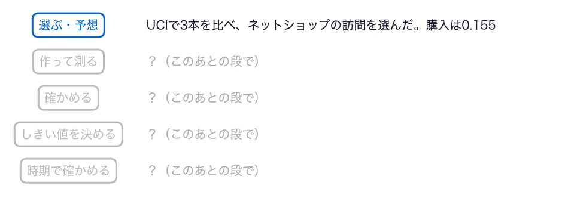

- まだ分からないのは、購入をどのくらい見分けられるか

## ノートへ：0〜2節

2節 ⑦ ノートへ●

- 0〜2節のセルを上から実行し、スライドと同じ数が出るか確かめる
- 予想を書く：12本の列のうち、いちばん効くのはどれか
- TODO①：予想を書く → `468`を`601`に替えて実行 → 予想と比べる

動画の人は、ここで一時停止。UCIにつながらないときは、ノートの「UCIにつながらないとき」のセルで、同じ表を読む。

## 答え合わせ：TODO①

2節 ⑧ 答え合わせ●

```
(10000, 6)
Machine failure    0.034
TWF                0.005
HDF                0.012
PWF                0.010
OSF                0.010
RNF                0.002
```

- 工作機械は10,000件、列6本。故障（Machine failure）は0.034で、もっと偏っている
- 答えの列が6本。故障そのものと、故障の種類5つ。ページで確かめる大切さ

# 3. 購入を見分けられる？

## 段2：作って測る

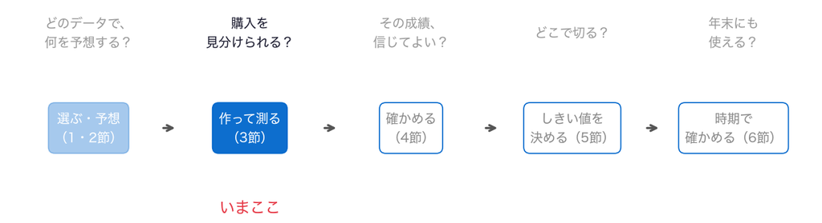

- 問い：12本の列から、購入をどのくらい見分けられるか

## 前の段から

3節 ① 前の段から●

- ネットショップの訪問を選び、12本の列と答えの列「購入」を用意した
- 購入は0.155。買った訪問は、商品ページに長くいた
- ここから、確率を出して、混同行列とAUCで測る（第6回の道具）

## 何も言わなくても0.845

3節 ② 正解率の罠●

```python
print(round(1 - df['購入'].mean(), 3))
```

```
0.845
```

- 全部「買わない」と言えば、買わない訪問がすべて当たる。正解率は1 − 0.155
- 正解率だけでは分からない。混同行列とAUCで測る（第6回）

## 単位がばらばら

3節 ③ 標準化●○○

- 商品ページ時間は秒で、いちばん長い訪問は6万秒を超える
- 直帰率や離脱率は、0〜0.2の割合
- 大きさがそろわないと、式の計算がうまく進まないことがある

## 標準化：第3回のおさらい

3節 ③ 標準化●●○

$$z_{ij} = \frac{x_{ij} - \bar{x}_j}{s_j}$$

- 列$j$ごとに、平均$\bar{x}_j$を引き、標準偏差$s_j$で割る。どの列も平均0、標準偏差1になる
- 平均と標準偏差は、訓練のデータだけで決める。テストにも、訓練の値を使う

## 道具：標準化と式をつなぐ

3節 ③ 標準化●●●

- `StandardScaler`：`fit`で列ごとの平均と標準偏差を覚え、`transform`で標準化する
- `make_pipeline(A, B)`：AとBをつなぎ、1つの式の作り方にする
- つないだ式の作り方を交差検証に渡すと、組ごとに、訓練の組だけで平均を覚える

## お手本：確率を出す

3節 ④ 確率を出す●○○○○○

```python
from sklearn.preprocessing import StandardScaler
from sklearn.linear_model import LogisticRegression
from sklearn.pipeline import make_pipeline
from sklearn.model_selection import cross_val_predict
model = make_pipeline(StandardScaler(), LogisticRegression())
p = cross_val_predict(model, df[cols], df['購入'], cv=5,
                      method='predict_proba')
df['確率'] = p[:, 1]
print(round(df['確率'].min(), 3), round(df['確率'].max(), 3))
```

```
0.001 1.0
```

## 1行ずつ：確率を出す①

3節 ④ 確率を出す●●○○○○

```python
from sklearn.preprocessing import StandardScaler
from sklearn.linear_model import LogisticRegression
from sklearn.pipeline import make_pipeline
from sklearn.model_selection import cross_val_predict
model = make_pipeline(StandardScaler(), LogisticRegression())
p = cross_val_predict(model, df[cols], df['購入'], cv=5,
                      method='predict_proba')
df['確率'] = p[:, 1]
print(round(df['確率'].min(), 3), round(df['確率'].max(), 3))
```

- 1〜4行目：標準化、ロジスティック回帰、つなぐ道具、交差検証の道具を呼び出す
- 5行目：標準化とロジスティック回帰をつなぎ、式の作り方`model`にしまう

## 1行ずつ：確率を出す②

3節 ④ 確率を出す●●●○○○

```python
from sklearn.preprocessing import StandardScaler
from sklearn.linear_model import LogisticRegression
from sklearn.pipeline import make_pipeline
from sklearn.model_selection import cross_val_predict
model = make_pipeline(StandardScaler(), LogisticRegression())
p = cross_val_predict(model, df[cols], df['購入'], cv=5,
                      method='predict_proba')
df['確率'] = p[:, 1]
print(round(df['確率'].min(), 3), round(df['確率'].max(), 3))
```

- 6・7行目：式の作り方、12本の列、答えの列を渡す。`cv=5`は5つの組
- `method='predict_proba'`で、どの訪問にも、自分を見ていない式から確率が付く（第6回）

## 1行ずつ：確率を出す③

3節 ④ 確率を出す●●●●○○

```python
from sklearn.preprocessing import StandardScaler
from sklearn.linear_model import LogisticRegression
from sklearn.pipeline import make_pipeline
from sklearn.model_selection import cross_val_predict
model = make_pipeline(StandardScaler(), LogisticRegression())
p = cross_val_predict(model, df[cols], df['購入'], cv=5,
                      method='predict_proba')
df['確率'] = p[:, 1]
print(round(df['確率'].min(), 3), round(df['確率'].max(), 3))
```

- 8行目：`p[:, 1]`（すべての行の、1番の列＝購入の確率）を、列「確率」にしまう
- 9行目：確率のいちばん小さい値と、いちばん大きい値を表示する

## make_pipelineがしていること

3節 ④ 確率を出す●●●●●○

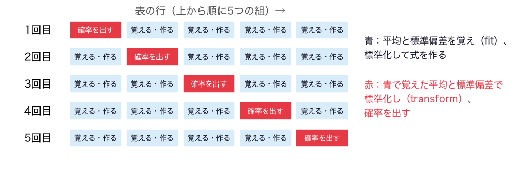

- 5回とも、確率を出す組（赤）を見ないで、平均と標準偏差を覚える
- 第3回で手で書いた「テストは訓練の平均と標準偏差で」を、道具が組ごとにやる

## 中身を見る：確率の列

3節 ④ 確率を出す●●●●●●

```python
df[['購入', '確率']].head(3)
```

|  | 購入 | 確率 |
| --- | --- | --- |
| 0 | 0 | 0.003592 |
| 1 | 0 | 0.035032 |
| 2 | 0 | 0.003592 |

- 1件に1つずつ、購入の確率が付いた。先頭の3件は、どれも確率が小さい

## お手本：確率を描く

3節 ⑤ 確率を描く●○○

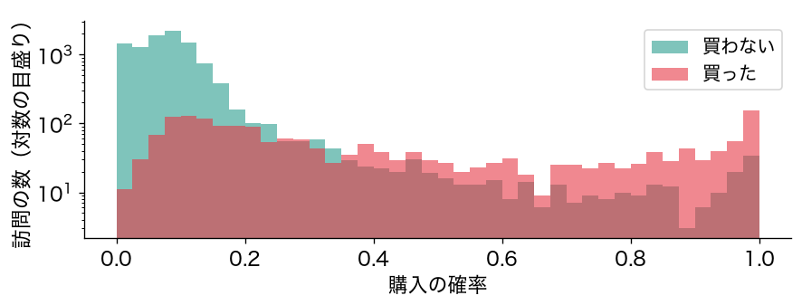

```python
plt.hist(df[df['購入'] == 0]['確率'], bins=40, alpha=0.6,
         label='買わない')
plt.hist(df[df['購入'] == 1]['確率'], bins=40, alpha=0.6,
         label='買った')
plt.yscale('log')
plt.xlabel('購入の確率')
plt.ylabel('訪問の数（対数の目盛り）')
plt.legend()
```

## 1行ずつ：確率を描く

3節 ⑤ 確率を描く●●○

```python
plt.hist(df[df['購入'] == 0]['確率'], bins=40, alpha=0.6,
         label='買わない')
plt.hist(df[df['購入'] == 1]['確率'], bins=40, alpha=0.6,
         label='買った')
plt.yscale('log')
plt.xlabel('購入の確率')
plt.ylabel('訪問の数（対数の目盛り）')
plt.legend()
```

- 1〜4行目：買わなかった訪問と買った訪問の確率を、40本の柱で重ねて描く
- 5行目：縦の目盛りを対数にする（0の近くの柱が高すぎて、ほかが見えないため）
- 6〜8行目：軸の名前と、色の説明（凡例）を付ける

## 買った訪問ほど、確率が高い

3節 ⑤ 確率を描く●●●

- 買わなかった訪問（緑）は、ほとんどが0の近くに集まる
- 買った訪問（赤）は、0から1まで広く散らばる
- 0の近くにも、買った訪問がかなりある。ここが見逃しになる

## お手本：0.5で切る

3節 ⑥ 0.5で切る●○○○

```python
from sklearn.metrics import confusion_matrix
df['判定'] = (df['確率'] >= 0.5).astype(int)
print(confusion_matrix(df['購入'], df['判定']))
```

```
[[10183   239]
 [ 1217   691]]
```

- 確率が0.5以上なら購入と判定し、混同行列を数える（第6回）

## 1行ずつ：0.5で切る

3節 ⑥ 0.5で切る●●○○

```python
from sklearn.metrics import confusion_matrix
df['判定'] = (df['確率'] >= 0.5).astype(int)
print(confusion_matrix(df['購入'], df['判定']))
```

- 1行目：混同行列の道具を呼び出す
- 2行目：確率が0.5以上ならTrue。`astype(int)`で1と0に直し、列「判定」にしまう
- 3行目：本当（購入）と判定を渡し、2×2の表を表示する

## 中身を見る：確率と判定

3節 ⑥ 0.5で切る●●●○

```python
df[['確率', '判定']].head(3)
```

|  | 確率 | 判定 |
| --- | --- | --- |
| 0 | 0.003592 | 0 |
| 1 | 0.035032 | 0 |
| 2 | 0.003592 | 0 |

- 確率が0.5より小さいので、3件とも判定は0（買わない）

## 0.5では、6割を見逃す

3節 ⑥ 0.5で切る●●●●

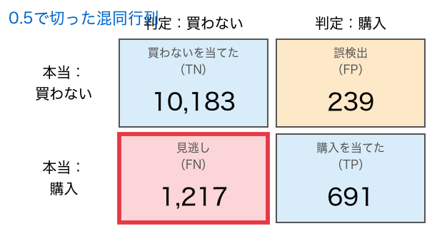

- 買った1,908件のうち、1,217件を見逃す。正解率は0.882（何もしなければ0.845）

## お手本：AUCを出す

3節 ⑦ AUC●○○

```python
from sklearn.metrics import roc_auc_score
print(round(roc_auc_score(df['購入'], df['確率']), 3))
```

```
0.877
```

- しきい値を決めずに、確率の付き方そのものを測る（第6回）

## 1行ずつ：AUCを出す

3節 ⑦ AUC●●○

```python
from sklearn.metrics import roc_auc_score
print(round(roc_auc_score(df['購入'], df['確率']), 3))
```

- 1行目：AUCの道具`roc_auc_score`を呼び出す
- 2行目：本当の答えと確率を渡すと、AUCが返る。しきい値は渡さない

## AUCは0.877

3節 ⑦ AUC●●●

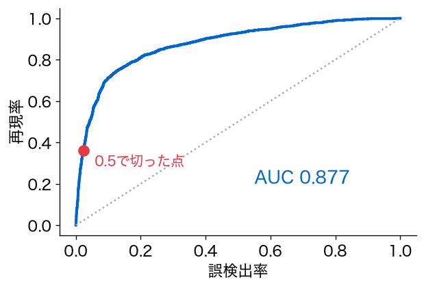

- 買った訪問1件と買わなかった訪問1件の組のうち、0.877の割合で、買った訪問の確率が高い

## TODO②：列を1本だけにする

3節 ⑧ 列を1本に●○

```python
# TODO: cols を ['商品ページ時間'] に替えて実行する
cols_x = cols
p = cross_val_predict(model, df[cols_x], df['購入'], cv=5,
                      method='predict_proba')
print(round(roc_auc_score(df['購入'], p[:, 1]), 3))
```

- 予想：商品ページにいた時間だけで確率を出すと、AUC（12本で0.877）はいくつになる？

## ここまでで分かったこと

3節 ⑧ 列を1本に●●

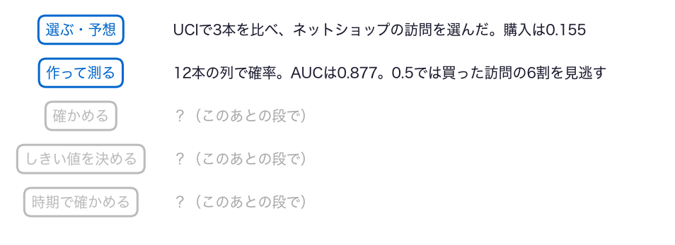

- まだ分からないのは、このAUCを信じてよいか。どの列が効いているか

## ノートへ：3節

3節 ⑨ ノートへ●

- 3節のセルを上から実行し、スライドと同じ数が出るか確かめる
- TODO②：予想を書く → `cols`を`['商品ページ時間']`に替えて実行 → 予想と比べる

動画の人は、ここで一時停止。

## 答え合わせ：TODO②

3節 10 答え合わせ●

```
12本 0.877  商品ページ時間だけ 0.655
```

- 商品ページにいた時間だけでは、AUCは0.655。12本の0.877より、ずっと低い
- 2節で差が見えた列でも、1本では見分けきれない

# 4. その成績、信じてよい？

## 段3：確かめる

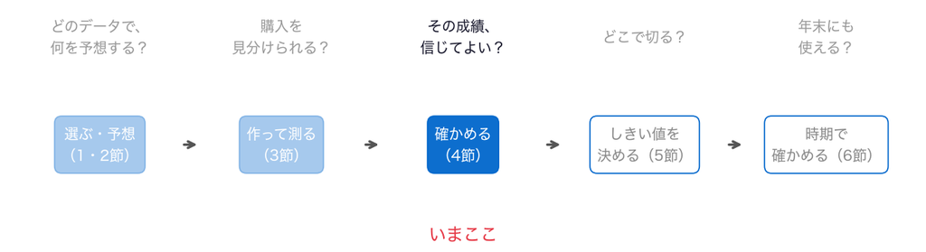

- 問い：AUC 0.877を、信じてよいか。どの列が効いているか

## 前の段から

- 12本の列で購入の確率を出し、AUCは0.877だった
- では、12本のうち、どの列が効いているのか
- 1本ずつ外して、AUCが下がるかを見る

## 同じ手順を、12回

4節 ① 関数●○○○○○○○

- 列を1本外して、確率を出し、AUCを測る。これを12本ぶん
- 同じ3行を12回書くのは、まちがいのもと
- 手順に名前を付けて、関数にまとめる

## 関数：第3回・第6回のおさらい

4節 ① 関数●●○○○○○○

```python
def double(x):
    return 2 * x

print(double(3))
print(double(10))
```

- `def 名前(入力):`の下の字下げした行が、関数の中身。呼ぶたびに動く
- `return`で答えを返す。入力を替えて呼ぶと、同じ手順が別の入力で動く

## お手本：手順を関数にまとめる

4節 ① 関数●●●○○○○○

```python
def auc_of(cols):
    p = cross_val_predict(model, df[cols], df['購入'], cv=5,
                          method='predict_proba')
    return round(roc_auc_score(df['購入'], p[:, 1]), 3)

print(auc_of(cols))
```

```
0.877
```

## 1行ずつ：関数にまとめる①

4節 ① 関数●●●●○○○○

```python
def auc_of(cols):
    p = cross_val_predict(model, df[cols], df['購入'], cv=5,
                          method='predict_proba')
    return round(roc_auc_score(df['購入'], p[:, 1]), 3)

print(auc_of(cols))
```

- 1行目：関数`auc_of`を作る。入力は、列の名前のリスト`cols`
- 2・3行目：3節と同じ。渡された列で、交差検証の確率を出す

## 1行ずつ：関数にまとめる②

4節 ① 関数●●●●●○○○

```python
def auc_of(cols):
    p = cross_val_predict(model, df[cols], df['購入'], cv=5,
                          method='predict_proba')
    return round(roc_auc_score(df['購入'], p[:, 1]), 3)

print(auc_of(cols))
```

- 4行目：AUCを出し、小数第3位までに丸めて返す
- 6行目：12本の列で呼ぶ。3節と同じ0.877が返る

## 中身を見る：入力を替えて呼ぶ

4節 ① 関数●●●●●●○○

```python
print(auc_of(['商品ページ時間']))
print(auc_of(['ページ価値']))
```

```
0.655
0.83
```

- 1行で、別の列の組を試せる。ページ価値1本だけで、0.830もある

## 関数は、手順に付けた名前

4節 ① 関数●●●●●●●○

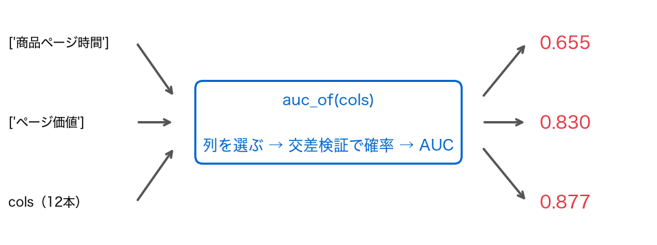

- 手順は1つ。入力（列の組）を替えて呼ぶたびに、同じ手順が動く

## 重要概念：関数

4節 ① 関数●●●●●●●●

関数は、手順に名前を付けたもの。入力を替えて呼ぶたびに、同じ手順が動き、答えを返す。

## お手本：1本ずつ外す

4節 ② 1本ずつ外す●○○○○

```python
for c in cols:
    rest = []
    for x in cols:
        if x != c:
            rest.append(x)
    print(c, auc_of(rest))
```

```
管理ページ数 0.877   管理ページ時間 0.877   情報ページ数 0.877
情報ページ時間 0.877   商品ページ数 0.876   商品ページ時間 0.876
直帰率 0.877   離脱率 0.882   ページ価値 0.718
特別な日 0.879   週末 0.877   新規 0.875
```

- 12本の列から1本ずつ外し、残りの11本でAUCを測る

## 1行ずつ：1本ずつ外す①

4節 ② 1本ずつ外す●●○○○

```python
for c in cols:
    rest = []
    for x in cols:
        if x != c:
            rest.append(x)
    print(c, auc_of(rest))
```

- 1行目：12本の列の名前を1つずつ`c`に入れ、字下げした行をくり返す。`c`が外す列
- 2行目：残す列をためる、空のリスト`rest`を作る

## 1行ずつ：1本ずつ外す②

4節 ② 1本ずつ外す●●●○○

```python
for c in cols:
    rest = []
    for x in cols:
        if x != c:
            rest.append(x)
    print(c, auc_of(rest))
```

- 3行目：もう一度、12本の列を1つずつ`x`に入れてくり返す
- 4・5行目：`x`が外す列`c`でなければ（`!=`）、`rest`の後ろに足す

## 1行ずつ：1本ずつ外す③

4節 ② 1本ずつ外す●●●●○

```python
for c in cols:
    rest = []
    for x in cols:
        if x != c:
            rest.append(x)
    print(c, auc_of(rest))
```

- 6行目：外した列の名前と、残りの11本で測ったAUCを表示する
- 関数があるので、くり返しの中身が1行で済む

## 中身を見る：残した列

4節 ② 1本ずつ外す●●●●●

```python
c = 'ページ価値'
rest2 = []
for x in cols:
    if x != c:
        rest2.append(x)
print(len(rest2), 'ページ価値' in rest2)
```

```
11 False
```

- 外す列をページ価値に決めて、1回だけ回した。11本が残り、ページ価値は入っていない

## えっ、1本だけ大きく下がる

4節 ③ えっ●○

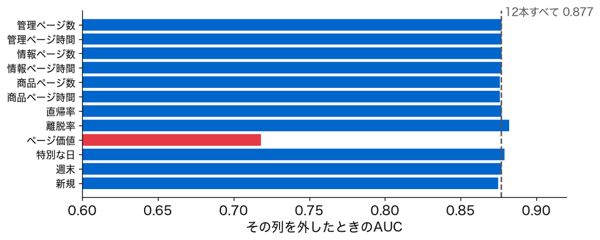

- ほかの列は、外してもAUCはほとんど変わらない（0.875〜0.882）
- ページ価値を外したときだけ、0.877から0.718に下がる

## 予想と比べる

4節 ③ えっ●●

- 予想は「いちばん効くのは、商品ページにいた時間」だった
- 実際は、ページ価値1本で、ほとんど決まっていた
- ページ価値とは、何なのか

## お手本：ページ価値がある訪問

4節 ④ ページ価値●○○○○○○

```python
df['価値あり'] = (df['ページ価値'] > 0).astype(int)
print(df.groupby('購入')['価値あり'].mean().round(3))
```

```
購入
0    0.114
1    0.806
```

- ページ価値が0より大きい訪問の割合を、買わなかった訪問と買った訪問で比べる

## 1行ずつ：ページ価値がある訪問

4節 ④ ページ価値●●○○○○○

```python
df['価値あり'] = (df['ページ価値'] > 0).astype(int)
print(df.groupby('購入')['価値あり'].mean().round(3))
```

- 1行目：ページ価値が0より大きければ1、0なら0の列「価値あり」を作る
- 2行目：購入の0と1で組に分け、「価値あり」の平均（1の割合）を出す

## 中身を見る：ページ価値と価値あり

4節 ④ ページ価値●●●○○○○

```python
df[['ページ価値', '価値あり', '購入']].head(3)
```

|  | ページ価値 | 価値あり | 購入 |
| --- | --- | --- | --- |
| 0 | 0.0 | 0 | 0 |
| 1 | 0.0 | 0 | 0 |
| 2 | 0.0 | 0 | 0 |

- 先頭の3件は、どれもページ価値が0なので、価値ありも0。購入も0

## 買った訪問の8割に価値

4節 ④ ページ価値●●●●○○○

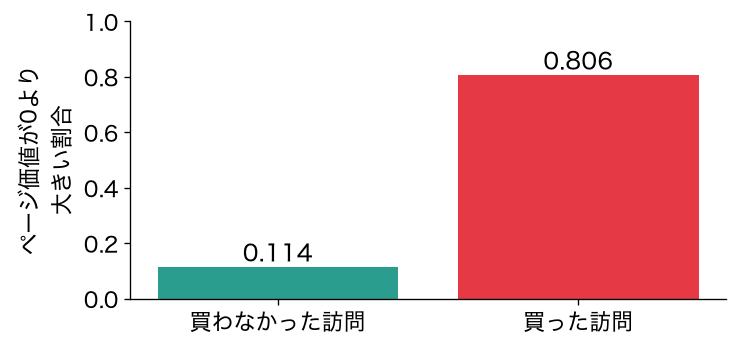

- 買わなかった訪問では0.114、買った訪問では0.806

## データの説明を読む

4節 ④ ページ価値●●●●●○○

- UCIのページには、こう書いてある
- 「The “Page Value” feature represents the average value for a web page that a user visited before completing an e-commerce transaction.」
- 訳：ページ価値は、購入を終える前に見たページの、価値の平均

## 購入から計算された列

4節 ④ ページ価値●●●●●●○

- ページの価値は、アクセス解析の道具（Google Analytics）が出す数
- 購入の売上を、その購入の前に見られたページに割り振って、ページごとに計算する
- 購入が無ければ、ページの価値は付かない。答え（購入）から作られた列

## 使ってよいか？

4節 ④ ページ価値●●●●●●●

- 過去の購入から、前もって計算しておいた値なら、訪問の途中でも分かる。使ってよい
- この訪問の購入まで入れて計算した値なら、答えを見ていることになる
- このデータの説明には、いつの購入から計算したかは書いていない

## お手本：ページ価値なしで切る

4節 ⑤ ページ価値なし●○○○

```python
no_pv = []
for x in cols:
    if x != 'ページ価値':
        no_pv.append(x)
p = cross_val_predict(model, df[no_pv], df['購入'], cv=5,
                      method='predict_proba')
judge = (p[:, 1] >= 0.5).astype(int)
print(confusion_matrix(df['購入'], judge))
print(judge.sum(), round((judge == df['購入']).mean(), 3))
```

```
[[10400    22]
 [ 1900     8]]
30 0.844
```

## 1行ずつ：ページ価値なしで切る

4節 ⑤ ページ価値なし●●○○

```python
no_pv = []
for x in cols:
    if x != 'ページ価値':
        no_pv.append(x)
p = cross_val_predict(model, df[no_pv], df['購入'], cv=5,
                      method='predict_proba')
judge = (p[:, 1] >= 0.5).astype(int)
print(confusion_matrix(df['購入'], judge))
print(judge.sum(), round((judge == df['購入']).mean(), 3))
```

- 1〜4行目：ページ価値を除いた11本の列を、リスト`no_pv`にためる
- 5・6行目：11本で、交差検証の確率を出す
- 7・8行目：0.5で切った判定を`judge`にしまい、混同行列を表示する
- 9行目：購入と判定した件数と、判定が当たった割合（正解率）を表示する

## 中身を見る：11本の列

4節 ⑤ ページ価値なし●●●○

```python
print(len(no_pv))
print(no_pv[-4:])
```

```
11
['離脱率', '特別な日', '週末', '新規']
```

- 11本。後ろの4本に、ページ価値は無い（離脱率の次が特別な日）

## 価値なしでは、ほぼ言えない

4節 ⑤ ページ価値なし●●●●

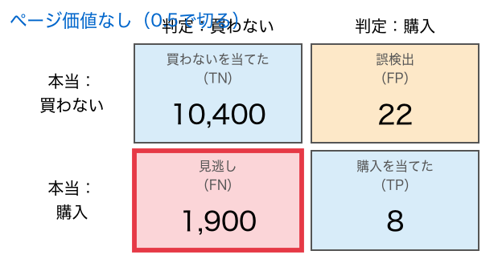

- 購入と判定したのは30件だけ。正解率0.844は、何も言わないとき（0.845）より低い

## どちらで進むか、決める

4節 ⑥ 決める●○

- 店が、過去の購入からページ価値を前もって計算している、と仮定する
- この仮定のもとで、ページ価値を入れた12本で進む
- 仮定が崩れたら、AUCは0.718まで下がる、と書き添える

## 重要：その列が何から作られたか

4節 ⑥ 決める●●

成績が良すぎる列は、データの説明を読み、何から作られた値かを確かめる。答えから作られた列なら、使ってよいかは、いつ計算したかで決まる。

## TODO③：外す列を替える

4節 ⑦ 外す列●○

```python
# TODO: 'ページ価値' を '離脱率' に替えて実行する
c = 'ページ価値'
rest_x = []
for x in cols:
    if x != c:
        rest_x.append(x)
print(auc_of(rest_x))
```

- 予想：離脱率を外すと、AUC（12本で0.877）はどうなる？

## ここまでで分かったこと

4節 ⑦ 外す列●●

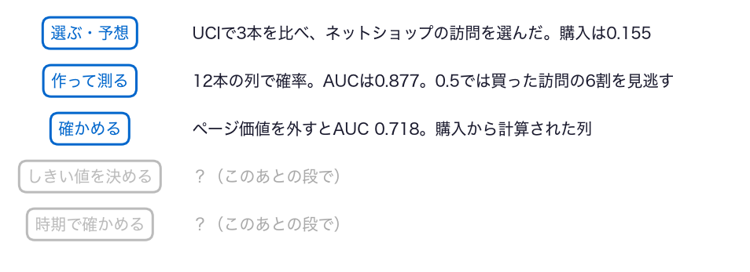

- まだ分からないのは、確率をどこで切ればよいか

## ノートへ：4節

4節 ⑧ ノートへ●

- 4節のセルを上から実行し、スライドと同じ数が出るか確かめる
- TODO③：予想を書く → `'ページ価値'`を`'離脱率'`に替えて実行 → 予想と比べる

動画の人は、ここで一時停止。

## 答え合わせ：TODO③

4節 ⑨ 答え合わせ●

```
12本 0.877  離脱率を外す 0.882  ページ価値を外す 0.718
```

- 離脱率を外すと0.882。下がるどころか、わずかに上がった
- 外しても困らない列もある。効いているのは、ページ価値だった

# 5. どこで切る？

## 段4：しきい値を決める

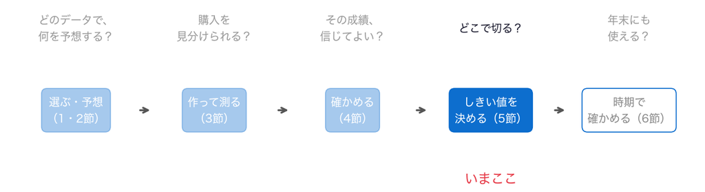

- 問い：確率をどこで切って、声をかける訪問を決めるか

## 前の段から

- 12本の列で確率を出し、AUCは0.877。ページ価値は、仮定を置いて使う
- 0.5で切ると、買った1,908件のうち1,217件を見逃す
- 0.5でよいのか。2つの誤りの重さから決める

## 声をかける場面

5節 ① 誤りの重さ●○○

- 確率がしきい値以上の訪問に、チャットの担当者が声をかける
- 見逃し：買う気のある訪問に、声をかけそびれる。売上の機会を逃す
- 誤検出：買わない訪問に、担当者の時間を使う

## 2つの誤りに、重さを置く

5節 ① 誤りの重さ●●○

$$\text{損の合計} = c_{FN} \times \text{見逃しの件数} + 1 \times \text{誤検出の件数}$$

- 誤検出1件の損を1とし、見逃し1件の損を$c_{FN}$とする
- ここでは、見逃しは誤検出の5倍重い（$c_{FN} = 5$）と置く。これは仮定

## 0.5で切ったときの損

5節 ① 誤りの重さ●●●

```
見逃し 1217  誤検出 239
損の合計 5 × 1217 + 239 = 6324
```

- 0.5で切ると、損の合計は6,324
- しきい値を下げると、見逃しが減り、誤検出が増える（第6回）。損はどうなるか

## お手本：しきい値ごとの損

5節 ② しきい値ごとの損●○○○○

```python
c_fn = 5
ts = []
costs = []
for k in range(1, 100):
    t = k / 100
    m = confusion_matrix(df['購入'], (df['確率'] >= t).astype(int))
    ts.append(t)
    costs.append(c_fn * m[1, 0] + m[0, 1])
print(ts[0], ts[-1], costs[49])
```

```
0.01 0.99 6324
```

## 1行ずつ：しきい値ごとの損①

5節 ② しきい値ごとの損●●○○○

```python
c_fn = 5
ts = []
costs = []
for k in range(1, 100):
    t = k / 100
    m = confusion_matrix(df['購入'], (df['確率'] >= t).astype(int))
    ts.append(t)
    costs.append(c_fn * m[1, 0] + m[0, 1])
print(ts[0], ts[-1], costs[49])
```

- 1行目：見逃し1件の重さ`c_fn`を5にする
- 2・3行目：しきい値をためるリスト`ts`と、損をためるリスト`costs`を、空で作る

## 1行ずつ：しきい値ごとの損②

5節 ② しきい値ごとの損●●●○○

```python
c_fn = 5
ts = []
costs = []
for k in range(1, 100):
    t = k / 100
    m = confusion_matrix(df['購入'], (df['確率'] >= t).astype(int))
    ts.append(t)
    costs.append(c_fn * m[1, 0] + m[0, 1])
print(ts[0], ts[-1], costs[49])
```

- 4行目：`k`を1から99まで1つずつ変えて、くり返す
- 5行目：`k / 100`で、しきい値`t`は0.01から0.99まで
- 6行目：しきい値`t`で切った判定の混同行列を、`m`にしまう

## 1行ずつ：しきい値ごとの損③

5節 ② しきい値ごとの損●●●●○

```python
c_fn = 5
ts = []
costs = []
for k in range(1, 100):
    t = k / 100
    m = confusion_matrix(df['購入'], (df['確率'] >= t).astype(int))
    ts.append(t)
    costs.append(c_fn * m[1, 0] + m[0, 1])
print(ts[0], ts[-1], costs[49])
```

- 7行目：しきい値を`ts`に足す
- 8行目：`m[1, 0]`は見逃し、`m[0, 1]`は誤検出（第6回）。損の合計を`costs`に足す
- 9行目：最初と最後のしきい値と、50番目（しきい値0.5）の損を表示する

## 中身を見る：最初の3回

5節 ② しきい値ごとの損●●●●●

```python
for k in range(1, 4):
    t = k / 100
    m = confusion_matrix(df['購入'], (df['確率'] >= t).astype(int))
    print(t, m[1, 0], m[0, 1], c_fn * m[1, 0] + m[0, 1])
```

```
0.01 3 9532 9547
0.02 7 9205 9240
0.03 14 8799 8869
```

- しきい値がとても低いと、見逃しは少ないが、誤検出が数千件。損は大きい

## お手本：損を描く

5節 ③ 損を描く●○○

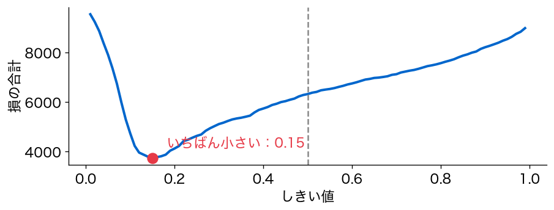

```python
plt.plot(ts, costs)
plt.xlabel('しきい値')
plt.ylabel('損の合計')
```

## 1行ずつ：損を描く

5節 ③ 損を描く●●○

```python
plt.plot(ts, costs)
plt.xlabel('しきい値')
plt.ylabel('損の合計')
```

- 1行目：横にしきい値、縦に損の合計を取り、99個の点を線でつなぐ
- 2・3行目：軸の名前を付ける

## 損には、谷がある

5節 ③ 損を描く●●●

- しきい値が低すぎると、誤検出で損が増える
- 高すぎると、見逃しで損が増える。0.5（破線）は、谷の底から遠い
- 谷の底のしきい値で切れば、損がいちばん小さい

## お手本：いちばん小さいところ

5節 ④ いちばん小さい●○○○○

```python
i = costs.index(min(costs))
print(ts[i], costs[i])
```

```
0.15 3749
```

- 見逃しを5倍と置くと、0.15で切るのが、損がいちばん小さい

## 1行ずつ：いちばん小さいところ

5節 ④ いちばん小さい●●○○○

```python
i = costs.index(min(costs))
print(ts[i], costs[i])
```

- 1行目：`min(costs)`で、いちばん小さい損を出す
- 続けて`costs.index(…)`で、それがリストの何番目かを調べ、`i`にしまう
- 2行目：`i`番目のしきい値と、そのときの損を表示する

## 中身を見る：indexの動き

5節 ④ いちばん小さい●●●○○

```python
a = [30, 10, 20]
print(min(a), a.index(min(a)))
```

```
10 1
```

- いちばん小さいのは10で、リストの1番目（0から数える）

## 0.15で切ると

5節 ④ いちばん小さい●●●●○

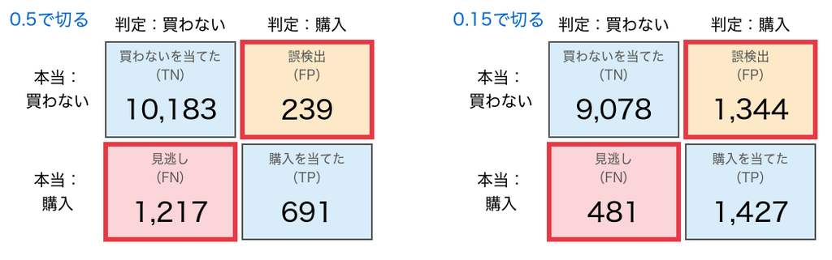

- 見逃しは1,217件から481件に減り、誤検出は239件から1,344件に増えた
- 損の合計は、6,324から3,749に下がる

## 重要概念：しきい値と重さ

5節 ④ いちばん小さい●●●●●

しきい値は0.5に決まっていない。見逃しと誤検出に重さを置き、損の合計がいちばん小さいところで切る。

## 重さを替えると

5節 ⑤ 重さを替える●○

```
重さ 1  しきい値 0.36  見逃し 1008  誤検出 368
重さ 2  しきい値 0.18  見逃し 595  誤検出 902
重さ 5  しきい値 0.15  見逃し 481  誤検出 1344
重さ 10  しきい値 0.12  見逃し 335  誤検出 2286
```

- 見逃しの重さ$c_{FN}$を1・2・5・10と替え、損がいちばん小さいしきい値を探した
- 見逃しを重くするほど、しきい値は下がり、たくさんの訪問に声をかける

## 重さは、データからは出てこない

5節 ⑤ 重さを替える●●

- 見逃し1件と誤検出1件の重さは、店が決める
- 1件の売上、担当者の数と時間、お客の印象などで決まる
- 期末レポートでは、重さを仮定として書き、替えたらどうなるかも見せる

## TODO④：見逃しの重さを替える

5節 ⑥ 見逃しの重さ●○

```python
# TODO: 5 を 1 に替えて実行する
c_fn = 5
costs_x = []
for t in ts:
    m = confusion_matrix(df['購入'], (df['確率'] >= t).astype(int))
    costs_x.append(c_fn * m[1, 0] + m[0, 1])
i = costs_x.index(min(costs_x))
print(ts[i], costs_x[i])
```

- 予想：見逃しと誤検出を同じ重さにすると、しきい値（5倍で0.15）はどうなる？

## ここまでで分かったこと

5節 ⑥ 見逃しの重さ●●

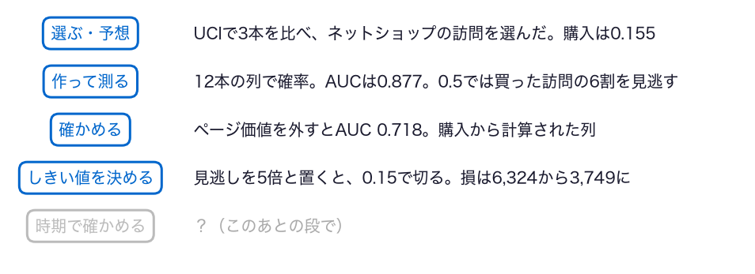

- まだ分からないのは、決めたしきい値が、これからの訪問にも使えるか

## ノートへ：5節

5節 ⑦ ノートへ●

- 5節のセルを上から実行し、スライドと同じ数が出るか確かめる
- TODO④：予想を書く → `5`を`1`に替えて実行 → 予想と比べる

動画の人は、ここで一時停止。

## 答え合わせ：TODO④

5節 ⑧ 答え合わせ●

```
重さ5 0.15  見逃し 481  誤検出 1344
重さ1 0.36  見逃し 1008  誤検出 368
```

- 同じ重さなら、しきい値は0.36。0.5ではない
- 確率は、ぴったり正しい確率とは限らない。だから、損を数えて決める

# 6. 年末にも使える？

## 段5：時期で確かめる

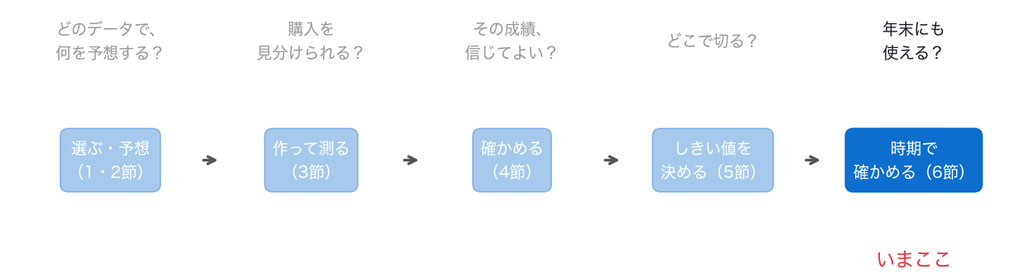

- 問い：手元のデータで決めたしきい値を、これからの訪問にも使ってよいか

## 前の段から

- 見逃しを5倍と置くと、0.15で切るのが、損がいちばん小さい
- ただし、そのしきい値は、手元の全部の訪問で決めた
- 実際には、決めたしきい値を、これからの訪問に使う。これからも、今までと同じか

## 時期で分けて確かめる

6節 ① 時期で分ける●○○

- 2〜10月の訪問で式を作り、しきい値を決める（過去）
- 11・12月の訪問に当てて、確率と損を測る（これから）
- 交差検証は時期を混ぜて分けるので、「これから」を確かめるには、時期で分ける

## お手本：時期で分ける

6節 ① 時期で分ける●●○

```python
late = df['Month'].isin(['Nov', 'Dec'])
early = ~late
print(early.sum(), late.sum())
print(round(df.loc[early, '購入'].mean(), 3),
      round(df.loc[late, '購入'].mean(), 3))
```

```
7605 4725
0.123 0.207
```

## 1行ずつ：時期で分ける

6節 ① 時期で分ける●●●

```python
late = df['Month'].isin(['Nov', 'Dec'])
early = ~late
print(early.sum(), late.sum())
print(round(df.loc[early, '購入'].mean(), 3),
      round(df.loc[late, '購入'].mean(), 3))
```

- 1行目：月が11月か12月ならTrue（`isin`）。年末の訪問
- 2行目：`~`でTrueとFalseを入れ替える。2〜10月の訪問
- 3〜5行目：訪問の数と、購入の割合。年末は購入が多い（0.123と0.207）

## お手本：過去で作り、年末に当てる

6節 ② 当てる●○○

```python
y_e = df.loc[early, '購入']
y_l = df.loc[late, '購入']
p_e = cross_val_predict(model, df.loc[early, cols], y_e, cv=5,
                        method='predict_proba')[:, 1]
model.fit(df.loc[early, cols], y_e)
p_l = model.predict_proba(df.loc[late, cols])[:, 1]
auc_e = roc_auc_score(y_e, p_e)
auc_l = roc_auc_score(y_l, p_l)
print(round(auc_e, 3), round(auc_l, 3))
```

```
0.906 0.826
```

## 1行ずつ：過去で作り、年末で測る

6節 ② 当てる●●○

```python
y_e = df.loc[early, '購入']
y_l = df.loc[late, '購入']
p_e = cross_val_predict(model, df.loc[early, cols], y_e, cv=5,
                        method='predict_proba')[:, 1]
model.fit(df.loc[early, cols], y_e)
p_l = model.predict_proba(df.loc[late, cols])[:, 1]
auc_e = roc_auc_score(y_e, p_e)
auc_l = roc_auc_score(y_l, p_l)
print(round(auc_e, 3), round(auc_l, 3))
```

- 1・2行目：過去と年末の、購入の列。3・4行目：過去の中だけで、交差検証の確率を出す（3節と同じ）
- 5・6行目：過去の全部で式を作り（`fit`）、年末の訪問の確率を出す（`predict_proba`）
- 7〜9行目：過去（交差検証）と年末のAUC。年末は0.906から0.826に下がる

## えっ、年末は低く見積もる

6節 ② 当てる●●●

```python
print(p_l.mean().round(3), y_l.mean().round(3))
```

```
0.148 0.207
```

- 年末の確率の平均は0.148。でも、実際に買ったのは0.207
- 過去の式は、年末の「買いやすさ」を知らない。見分ける力（AUC）も下がった

## しきい値を決める手順を関数に

6節 ③ 関数●○○

- 過去と年末で、同じ「損を数えて、いちばん小さい所を探す」をくり返す
- 5節の手順を、関数にまとめる（4節の関数と同じ考え）
- 損を出す関数と、いちばん小さいしきい値を返す関数の2つ

## お手本：2つの関数

6節 ③ 関数●●○

```python
def cost_at(y, p, t, c_fn):
    m = confusion_matrix(y, (p >= t).astype(int))
    return c_fn * m[1, 0] + m[0, 1]


def best_threshold(y, p, c_fn):
    costs = []
    for k in range(1, 100):
        costs.append(cost_at(y, p, k / 100, c_fn))
    i = costs.index(min(costs))
    return (i + 1) / 100
```

- `cost_at`：しきい値`t`で切ったときの損。`best_threshold`：損がいちばん小さいしきい値

## 1行ずつ：2つの関数

6節 ③ 関数●●●

```python
def cost_at(y, p, t, c_fn):
    m = confusion_matrix(y, (p >= t).astype(int))
    return c_fn * m[1, 0] + m[0, 1]


def best_threshold(y, p, c_fn):
    costs = []
    for k in range(1, 100):
        costs.append(cost_at(y, p, k / 100, c_fn))
    i = costs.index(min(costs))
    return (i + 1) / 100
```

- 6・7行目：入力は答え`y`・確率`p`・重さ`c_fn`。損をためるリストを作る
- 8・9行目：しきい値0.01〜0.99で、1つ目の関数`cost_at`を呼んで損をためる
- 10・11行目：いちばん小さい損の位置から、しきい値を返す（`i`番目は`(i + 1) / 100`）

## お手本：過去で決め、年末で測る

6節 ④ 測る●○○○

```python
t_e = best_threshold(y_e, p_e, 5)
t_l = best_threshold(y_l, p_l, 5)
print(t_e, t_l)
print(cost_at(y_l, p_l, t_e, 5), cost_at(y_l, p_l, t_l, 5))
```

```
0.12 0.09
2289 2123
```

## 1行ずつ：過去で決め、年末で測る

6節 ④ 測る●●○○

```python
t_e = best_threshold(y_e, p_e, 5)
t_l = best_threshold(y_l, p_l, 5)
print(t_e, t_l)
print(cost_at(y_l, p_l, t_e, 5), cost_at(y_l, p_l, t_l, 5))
```

- 1行目：過去で決めたしきい値（0.12）。2行目：年末の答えを知っていたら選べた、年末の最良（0.09）
- 3・4行目：2つのしきい値と、年末の損。過去で決めたほうが、166だけ損が大きい

## 年末の損の谷

6節 ④ 測る●●●○

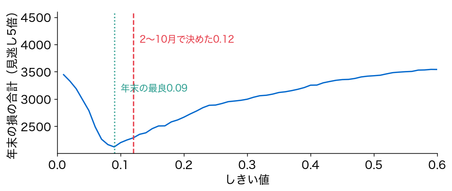

- 年末の谷の底は0.09。過去で決めた0.12は、底から少し右にずれる

## 重要：時期が変わると、ずれる

6節 ④ 測る●●●●

購入の割合や見分ける力は、時期で変わる。手元で決めたしきい値は、新しい時期のデータで確かめ直す。

## TODO⑤：重さを10にする

6節 ⑤ 重さ10●○

```python
# TODO: 5 を 10 に替えて実行する
c_fn = 5
t_e = best_threshold(y_e, p_e, c_fn)
t_l = best_threshold(y_l, p_l, c_fn)
print(t_e, t_l)
print(cost_at(y_l, p_l, t_e, c_fn), cost_at(y_l, p_l, t_l, c_fn))
```

- 予想：見逃しをもっと重くすると、過去で決めたしきい値のずれは大きくなるか

## ここまでで分かったこと

6節 ⑤ 重さ10●●

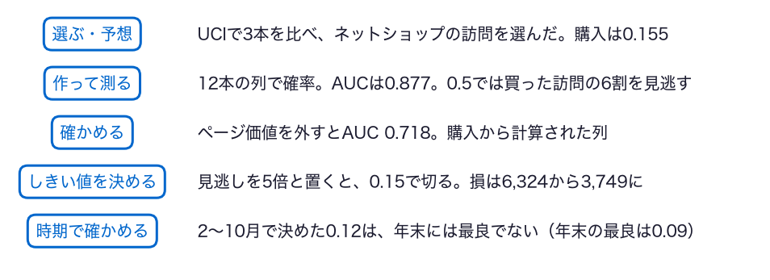

- 5つの段がそろい、今日の問いに答えられる

## ノートへ：6節

6節 ⑥ ノートへ●

- 6節のセルを上から実行し、スライドと同じ数が出るか確かめる
- TODO⑤：予想を書く → `5`を`10`に替えて実行 → 予想と比べる

動画の人は、ここで一時停止。

## 答え合わせ：TODO⑤

6節 ⑦ 答え合わせ●

```
0.1 0.06
3962 3099
```

- 重さ10では、過去で決めた0.1と年末の最良0.06の差が広がり、損の差は863になる
- 見逃しを重くするほど、年末の「買いやすさ」を見落とした分が、大きく効く

## 答え：重さを置いて切る

6節 ⑧ 答え●

- 12本の列でロジスティック回帰の確率を出すと、AUCは0.877
- 効いているのはページ価値。購入から計算された列なので、仮定を置いて使う
- 見逃しを誤検出の5倍と置くと、0.15で切るのが、損がいちばん小さい

## まだ言えないこと

6節 ⑨ まだ言えないこと●

- ページ価値の仮定：いつの購入から計算したかは、店に聞かないと分からない
- 重さ：5倍という数は仮定。実際の売上と担当者の時間から決めたい
- 声をかけたら買うか：このデータは、声をかけなかったときの記録

# まとめ

## 今日の道筋を振り返る

⑨ 振り返る●○○○

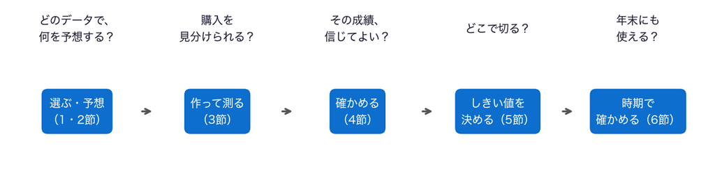

- データを選び、予想を書き、確率を出して測り、列を確かめ、重さでしきい値を決め、時期で確かめた

## 今日持ち帰る1文

⑨ 振り返る●●○○

しきい値は0.5に決まっていない。見逃しと誤検出の重さを置けば、しきい値が決まる。そして、成績を決めている列が何から作られたかを、データの説明で確かめる。

## 今日の重要概念

⑨ 振り返る●●●○

統計：しきい値は0.5に決まっていない。見逃しと誤検出に重さを置き、損の合計がいちばん小さいところで切る。

Python：関数は、手順に名前を付けたもの。入力を替えて呼ぶたびに、同じ手順が動き、答えを返す。

## 今日の要点

⑨ 振り返る●●●●

- データは、ページの説明まで読んで選ぶ。作ったデータか、人を判定しないか
- 手順を関数にすると、列の組を替えて何度も確かめられる
- 成績が良すぎる列は、何から作られたかを確かめる。重さは仮定として書く

## レポートなら、こう書く①

10 レポートなら●○

- 選んだ理由：実際のネットショップの記録で、1行が身近。作ったデータの2本は外した
- 予想：いちばん効くのは、商品ページにいた時間だろう
- 解析：12本の列でロジスティック回帰の確率を出し、AUCは0.877

## レポートなら、こう書く②

10 レポートなら●●

- 確かめた：1本ずつ外すと、ページ価値だけで0.718に下がる。説明を読み、仮定を置いた
- 驚き：予想した商品ページの時間ではなく、ページ価値1本でほぼ決まっていた
- 決めた：見逃しを5倍と置き、0.15で切る。重さを替えた表も付ける

## 課題の出し方

11 このあと●○○

- 今日の重要概念は、統計の「しきい値は誤りの重さで決める」と、Pythonの関数
- 2つを1枚ずつ絵にし、2枚をLACSに提出（＝出席。期限なし）
- 手描きの写真でも、描画アプリでもよい。上手でなくてよい

## 次回の問い

11 このあと●●○

- 今日は、答えの列（購入）があるデータで、確率を出して切った
- 答えの列が無いとき、似た行をまとめて、群に分けられるか

## このあと：課題へ

11 このあと●●●

- ノートの最後の「課題（提出）」を開く
- 絵を描き終えたら、このあとの「解答」で、絵の例と見比べる

# ここから先は解答

## 課題のあとで見る

- ここから先は、課題の絵を描き終えてから見る
- 絵の例を2つ見せる。上手さではなく、考えが伝わるかを見比べる

## 絵の例：しきい値と誤りの重さ

- 天気予報を見て、傘を持っていくか
- 濡れるのがとても嫌なら、降水確率20%でも持っていく
- 荷物が重いのが嫌なら、70%まで持たない。同じ予報でも、重さで決め方が変わる

## 絵の例：関数

- 炊飯器の「炊く」ボタン
- 手順（水を吸わせる、加熱する、蒸らす）は1つ。お米を替えて押すたびに、同じ手順が動く
- 入力（お米）を入れると、答え（ごはん）が返る

# 発展（任意）

## 月も、手がかりにしたら？

- 購入の割合は、月で違う（11月は0.254、2月は0.016）

```
{'Aug': 0.176, 'Dec': 0.125, 'Feb': 0.016, 'Jul': 0.153, 'June': 0.101, 'Mar': 0.101, 'May': 0.109, 'Nov': 0.254, 'Oct': 0.209, 'Sep': 0.192}
```

- 月を0と1の列にして足すと、AUCは上がるか
- `pd.get_dummies`は、月ごとに「その月なら1」の列を作る道具

## お手本：月を足す

```python
mon = pd.get_dummies(df['Month'], dtype=int)
X_mon = pd.concat([df[cols], mon], axis=1)
p = cross_val_predict(model, X_mon, df['購入'], cv=5,
                      method='predict_proba')
print(round(roc_auc_score(df['購入'], p[:, 1]), 3))
```

```
0.859
```

- 月を足したら、0.877から0.859に下がった

## 1行ずつ：月を足す

```python
mon = pd.get_dummies(df['Month'], dtype=int)
X_mon = pd.concat([df[cols], mon], axis=1)
p = cross_val_predict(model, X_mon, df['購入'], cv=5,
                      method='predict_proba')
print(round(roc_auc_score(df['購入'], p[:, 1]), 3))
```

- 1行目：月ごとの0と1の列（10か月ぶん）を作る
- 2行目：12本の列と月の列を、横につなぐ
- 3〜5行目：交差検証の確率を出し、AUCを表示する

## 組ごとの月

```python
fold = np.arange(len(df)) * 5 // len(df) + 1
pd.crosstab(fold, df['Month'])[['Feb', 'Mar', 'May', 'Nov', 'Dec']]
```

| Month 組 | Feb | Mar | May | Nov | Dec |
| --- | --- | --- | --- | --- | --- |
| 1 | 184 | 1907 | 375 | 0 | 0 |
| 2 | 0 | 0 | 2466 | 0 | 0 |
| 3 | 0 | 0 | 523 | 284 | 0 |
| 4 | 0 | 0 | 0 | 1224 | 751 |
| 5 | 0 | 0 | 0 | 1490 | 976 |

- 表はほぼ月の順。上から5つに分けると、2月と3月は1つ目の組にしかない
- 1つ目の組の確率を出すとき、式は2月と3月を一度も見ていない

## 混ぜて分けると

```python
from sklearn.model_selection import KFold
shuf = KFold(5, shuffle=True, random_state=0)
p = cross_val_predict(model, X_mon, df['購入'], cv=shuf,
                      method='predict_proba')
print(round(roc_auc_score(df['購入'], p[:, 1]), 3))
```

```
上から順の5組  12本 0.877  月を足す 0.859
混ぜた5組      12本 0.883  月を足す 0.894
```

- `KFold(5, shuffle=True)`は、行を混ぜてから5組に分ける。月を足して0.894に上がる
- どちらが正しいかは、何を当てたいかで決まる。来月を当てたいなら、上から順のほうが近い

## おわり

- お疲れさまでした